# GC content and dropout in the Patel data set

Thomas Willis

12 December 2020

The count matrix as stored in the file is not really a count matrix:

- the first three columns contain row numbers, gene names/symbols, and ENSEMBL IDs, respectively
- the first row (not the header) contains descriptions of each sample, indicating whether it is a single-cell or population sample, tumour or gliomasphere etc.

Note that this data set contains no spike-ins.

Starting with cells from a single batch-tumour pairing (although we only have one sample sequenced in two batches, MGH26). We really need some smarter QC here. I am unsure of how to normalise the counts prior to the log-transform and PCA, given my recent reading on the instability of the median-of-ratios depth normalisation technique when applied to scRNA-Seq data.

We take a subset of genes which have, on average, 5 counts per cell. Risso et al. used a threshold of 5+ counts in at least 5 cells in a 130-cell data set in the ZINB-WaVE vignette.

```r
sce_MGH26<-sce[,sce$Batch=="MGH26"]

rowData(sce_MGH26)$rowSums<-rowSums(counts(sce_MGH26))
rowData(sce_MGH26)$zeroFraction<-rowSums(counts(sce_MGH26)==0)/ncol(sce_MGH26)

# Subset of genes taken by an average detection threshold of 5 counts per cell
rowSubset(sce_MGH26, field="detected")<-rowData(sce_MGH26)$rowSums>=(ncol(sce_MGH26)*5)

sce_MGH26<-runPCA(sce_MGH26, subset_row=rowSubset(sce_MGH26, field="detected"), exprs_values="logcounts")
```

[figure not shown]

```r
plotPCA(sce_MGH26)
```

Perhaps I should be getting the mature transcript length and GC content? I believe this is just giving me the length and GC content of the genomic gene sequences.

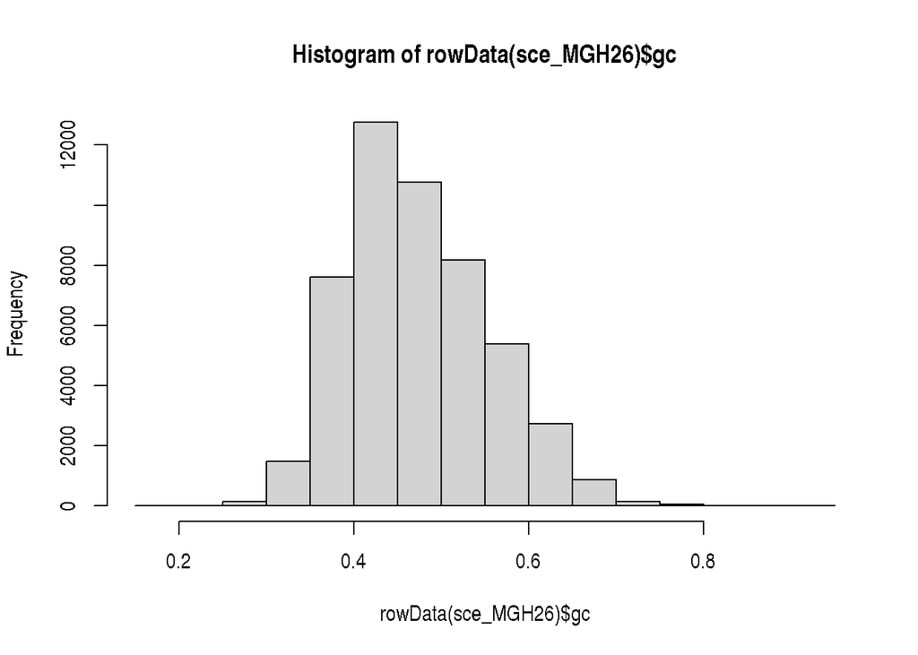

```r
hist(rowData(sce_MGH26)$gc)
```

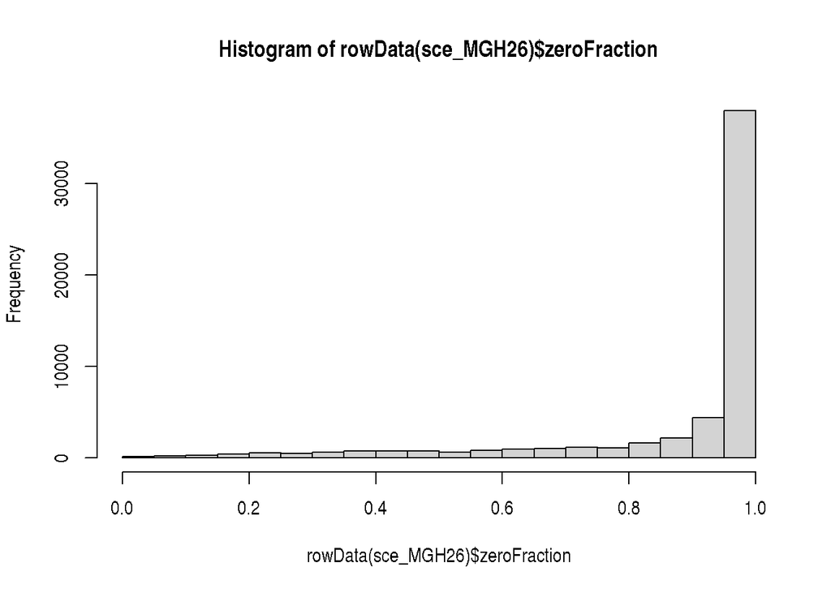

```r
hist(rowData(sce_MGH26)$zeroFraction)
```

[figure not shown]

```r
ggplot(data.frame(gc=-log(rowData(sce_MGH26)$gc), zf=-log(rowData(sce_MGH26)$zeroFraction)))+
  geom_point(aes(x=gc,y=zf), alpha=0.025)+
  xlab("-log(GC)")+
  ylab("-log(ZF+1)")+
  ggtitle("GC content vs. zero fraction, log scales")
```

Should we have GC content as a covariate for the mean as well as the ZI parameter?

```r
sce_MGH26_sub<-sce_MGH26[rowSubset(sce_MGH26, 'detected') & !is.na(rowData(sce_MGH26)$gc),]

# 590s for gc model on 11 cores on Tom's work laptop, then 659s
tic()
sce_MGH26_zwModel<-zinbFit(
  Y=sce_MGH26_sub,
  which_assay='counts',
  K=2,
  X='~1',
  V='~gc',
  )
toc()
```

```
## 550.483 sec elapsed
```

Do I need any special treatment of GC content as a variable restricted to the interval $[0,1]$? In the ZINB-WaVE vignette, Risso used it directly, i.e. without something like a log transform.

Is ZINB-WaVE even the right tool for the job? I’m not interested in finding sources of unwanted variation, after all, or finding a low-dimensional representation of the data.

Is the optimisation actually converging in the end or are we just hitting the max. no. of iterations?